# HW2_Valentine

### 6. For questions 1a - 1c, assume a variable is normally distributed with a mean of 180 and a standard deviation of 25. Please show all work (i.e., relevant code - hint: the `pnorm`/`qnorm`/`dnorm` family will be your friend here)

#### a. What is the probability that a single draw from this distribution, labeled X, will be greater than 210?

```r
#Formula will be pnorm(greater than value, mean, standard deviation)
#We are looking for greater than, so we lower tail = false
pnorm(210,180,25,lower.tail=FALSE)
```

```
## [1] 0.1150697
```

Probability is .1150697

#### b. What is the probability that a single draw from this distribution, labeled Y, will be less than 182?

```r
#Formula will be pnorm(less than value, mean, standard deviation)
#We are looking for greater than, so we lower tail = true
pnorm(182,180,25,lower.tail=TRUE)
```

```
## [1] 0.5318814
```

#### c. What is the probability that a single draw from this distribution, labeled Z, will be between 160 and 192?

```r
#We use the same type of formulas or above, then subtract them from one and then each other.
1- pnorm(160,180,25,lower.tail=TRUE) - pnorm(192,180,25,lower.tail=FALSE)
```

```
## [1] 0.4725309
```

### 7. The random variable x has the discrete probability distribution shown here:

| x | -2 | -1 | 0 | 1 | 2 |
| --- | --- | --- | --- | --- | --- |
| p(x) | 0.15 | 0.15 | 0.35 | 0.25 | 0.10 |

#### a. Find $P(x<=0)$

```r
#To calculate the probability that x is less than or equal to 0, we add the probabilities from the table that are associated with all negative and 0 values.

0.15+0.15+0.35
```

```
## [1] 0.65
```

#### b. Find $P(x>-1)$

```r
#To calculate the probability that x is greater than or equal to -1, we add the probabilities from the table that are above -1.

0.35+0.25+0.10
```

```
## [1] 0.7
```

#### c. Find $P(-1<=x<=1)$

```r
#To calculate the probability that x is greater than or equal to -1 AND less than or equal to 1, we add the probabilities above and below those limits that are present in the table above:

0.15 + 0.35 + 0.25
```

```
## [1] 0.75
```

#### d. Find $P(x<2)$

```r
#To calculate the probability that x is less than 2, we take a certain probability (100% or 1) and subtract the probability of 2 from the table above:

1-0.10
```

```
## [1] 0.9
```

#### e. Find $P(-1<x<2)$

```r
#To calculate the probability that x is greater than -1 and less than 2, we add the probability associated with 0 and 1 on the table above:

0.25 + 0.35
```

```
## [1] 0.6
```

### 9. Consider flipping an unequally weighted coin with probability of success $.55$. Say that $X$ is the random variable associated with this coin and that $X=1$ if heads (success), 0 otherwise. Simulate 20 coin flips and store them as a variable called “cflip.” In R, do this with `cflip=rbinom(20,1,.55)`. Use `?rbinom` to make sure you understand what each part of the command stands for.

```r
cflip=rbinom(20,1,.55)
```

Note to self: we use rbinom because the coin flip has a binomial distribution

#### a. Take 20 samples with replacement from cflip and compute the mean of the sample. In R: `cflipsamp=sample(cflip,20,replace=T)`

```r
cflipsamp=sample(cflip,20,replace=T)
```

#### b. Repeat step B (but not step A) 500 times, storing the mean of the sample each time. You could do this using a “for” loop to repeat the same step many times. An example of code for a loop is below. However, try to find a non-loop way of accomplishing the same thing (e.g., the `replicate` function).

`resamp.mean=rep(NA,500) for(i in 1:500){ resamp.mean[i]<-mean(sample(cflip,20,replace=T))}`.

```r
cflip500samp = replicate(500,mean(sample(cflip,20,replace=T)))
```

#### c. Plot a histogram of the re-sampled means. Does it look like what we know from normal theory that the sampling distribution of the mean should look like in this case?

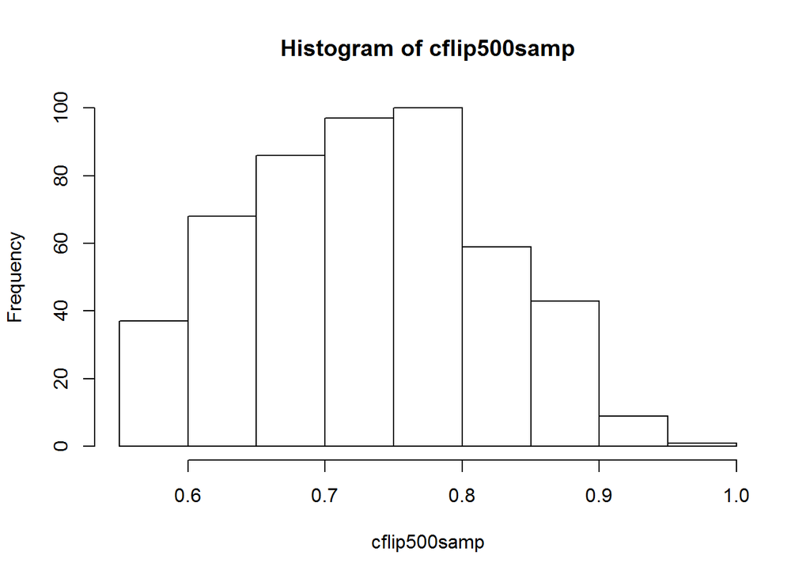

```r
hist(cflip500samp)
```